# > **Tip**: Welcome to the Investigate a Dataset project! You will find tips in quoted sections like this to help organize your approach to your investigation. Once you complete this project, remove th

# cleaning

Summary of Cleaning Decisions: To address the research questions effectively, several cleaning decisions have been made:

Eliminate redundant columns: homepage, tagline, imdb_id, overview, budget_adj, revenue_adj. Remove duplicate entries. Discard columns with a limited number of null values: cast, director, and genres. Replace zero values in the budget and revenue columns with null values. Exclude columns with a minimal number of zero values: runtime. Data Cleaning: In accordance with the aforementioned decisions, the initial step involves discarding unnecessary columns: imdb_id, homepage, tagline, and overview.

```python
# After discussing the structure of the data and any problems that need to be
#   cleaned, perform those cleaning steps in the second part of this section.
# Handling missing values: Drop rows with any missing values
#we can drop some columns for readability
df=df.drop(['cast', 'homepage', 'tagline', 'keywords', 'overview', 'imdb_id'], axis=1)
```

```python
df = df.dropna()
```

```python
df.info()
```

[output not shown]

```python
# Drop extraneous columns
col = ['imdb_id', 'homepage', 'tagline', 'overview', 'budget_adj', 'revenue_adj']
df.drop(col, axis=1, inplace=True)
```

```python
#Drop the duplicates
df.drop_duplicates(inplace=True)
```

```python
#drop the null values in cast, director, genres columns
cal2 = ['cast', 'director', 'genres']
df.dropna(subset = cal2, how='any', inplace=True)
```

```python
# see if nulls are dropped.
df.isnull().sum()
```

```
id                         0
popularity                 0
budget                     0
revenue                    0
original_title             0
cast                       0
director                   0
keywords                1425
runtime                    0
genres                     0
production_companies     959
release_date               0
vote_count                 0
vote_average               0
release_year               0
dtype: int64
```

```python
#replace zero values with null values in the budget and revenue column.
df['budget'] = df['budget'].replace(0, np.NaN)
df['revenue'] = df['revenue'].replace(0, np.NaN)
# see if nulls are added in budget and revenue columns
df.info()
```

```
<class 'pandas.core.frame.DataFrame'>
Int64Index: 10731 entries, 0 to 10865
Data columns (total 15 columns):
 #   Column                Non-Null Count  Dtype
---  ------                --------------  -----
 0   id                    10731 non-null  int64
 1   popularity            10731 non-null  float64
 2   budget                5153 non-null   float64
 3   revenue               4843 non-null   float64
 4   original_title        10731 non-null  object
 5   cast                  10731 non-null  object
 6   director              10731 non-null  object
 7   keywords              9306 non-null   object
 8   runtime               10731 non-null  int64
 9   genres                10731 non-null  object
 10  production_companies  9772 non-null   object
 11  release_date          10731 non-null  object
 12  vote_count            10731 non-null  int64
 13  vote_average          10731 non-null  float64
 14  release_year          10731 non-null  int64
dtypes: float64(4), int64(4), object(7)
memory usage: 1.3+ MB
```

```python
# directly filter the runtime data with nonzero value
df.query('runtime != 0', inplace=True)
#check
df.query('runtime == 0')
```

|  | id | popularity | budget | revenue | original_title | cast | director | keywords | runtime | genres | production_companies | release_date | vote_count | vote_average | release_year |
| --- | --- | --- | --- | --- | --- | --- | --- | --- | --- | --- | --- | --- | --- | --- | --- |

```
array([[<AxesSubplot: title={'center': 'id'}>,
        <AxesSubplot: title={'center': 'popularity'}>,
        <AxesSubplot: title={'center': 'budget'}>],
       [<AxesSubplot: title={'center': 'revenue'}>,
        <AxesSubplot: title={'center': 'runtime'}>,
        <AxesSubplot: title={'center': 'vote_count'}>],
       [<AxesSubplot: title={'center': 'vote_average'}>,
        <AxesSubplot: title={'center': 'release_year'}>, <AxesSubplot: >]],
      dtype=object)
```

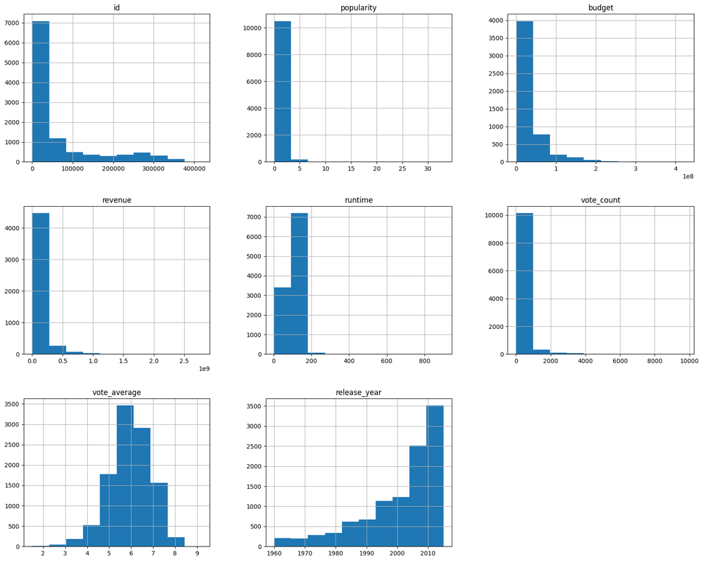

```python
df.hist(figsize=(20,16))
```

```python
#dropping the null values
df.dropna(inplace=True)
df.info()
```

```
<class 'pandas.core.frame.DataFrame'>
Int64Index: 3677 entries, 0 to 10848
Data columns (total 15 columns):
 #   Column                Non-Null Count  Dtype
---  ------                --------------  -----
 0   id                    3677 non-null   int64
 1   popularity            3677 non-null   float64
 2   budget                3677 non-null   float64
 3   revenue               3677 non-null   float64
 4   original_title        3677 non-null   object
 5   cast                  3677 non-null   object
 6   director              3677 non-null   object
 7   keywords              3677 non-null   object
 8   runtime               3677 non-null   int64
 9   genres                3677 non-null   object
 10  production_companies  3677 non-null   object
 11  release_date          3677 non-null   object
 12  vote_count            3677 non-null   int64
 13  vote_average          3677 non-null   float64
 14  release_year          3677 non-null   int64
dtypes: float64(4), int64(4), object(7)
memory usage: 459.6+ KB
```

```python
# Convert release_date (object datatype) to date.

df['release_date'] = pd.to_datetime(df['release_date'])
```

```python
#replace 0 values with means in columns budget and revenue.
df['budget'] = df['budget'].replace(0,df['budget'].mean())

df['revenue'] = df['revenue'].replace(0,df['revenue'].mean())
```

```python
df['genres'] = df['genres'].apply(lambda x: x.split('|')[0])
df['production_companies'] = df['production_companies'].apply(lambda x: x.split('|')[0])
```

```python
df.head()
```

[output not shown]

# cleaning summary

```python
df.describe()
```

|  | id | popularity | budget | revenue | runtime | vote_count | vote_average | release_year |
| --- | --- | --- | --- | --- | --- | --- | --- | --- |
| count | 3677.000000 | 3677.000000 | 3.677000e+03 | 3.677000e+03 | 3677.000000 | 3677.000000 | 3677.000000 | 3677.000000 |
| mean | 39224.526244 | 1.226051 | 3.811465e+07 | 1.114405e+08 | 109.561327 | 547.702203 | 6.182758 | 2001.091923 |
| std | 67249.633137 | 1.498897 | 4.267577e+07 | 1.793625e+08 | 19.855075 | 894.954704 | 0.789610 | 11.380391 |
| min | 5.000000 | 0.010335 | 1.000000e+00 | 2.000000e+00 | 26.000000 | 10.000000 | 2.200000 | 1960.000000 |
| 25% | 5470.000000 | 0.481276 | 1.000000e+07 | 1.489942e+07 | 96.000000 | 78.000000 | 5.700000 | 1995.000000 |
| 50% | 11017.000000 | 0.830597 | 2.500000e+07 | 4.806344e+07 | 106.000000 | 219.000000 | 6.200000 | 2004.000000 |
| 75% | 37958.000000 | 1.411147 | 5.000000e+07 | 1.298324e+08 | 120.000000 | 596.000000 | 6.700000 | 2010.000000 |
| max | 417859.000000 | 32.985763 | 4.250000e+08 | 2.781506e+09 | 338.000000 | 9767.000000 | 8.400000 | 2015.000000 |

# Exploratory

Exploratory Data Analysis Research Part 1: General Exploration

Question 1: Evolution of Popularity Over the Years Question 2: Examining the distribution of popularity across different revenue levels in the recent five years. Question 3: Analyzing the distribution of score ratings across different revenue levels in the recent five years.

Research Part 2: Identifying Properties Associated with Successful Movies

Question 1: What characteristics are commonly linked with movies that achieve high popularity? Question 2: What attributes are associated with movies that receive high voting scores?

*Research Part 3: Trends in Top Keywords and Genres by Generation

Question 1: Observing the number of movies released year by year. Question 2: Investigating trends in keywords by generation. Question 3: Exploring trends in genres by generation.

Research Part 1: General Exploration

Question 1: Popularity Over the Years To delve into this query, let's examine the dataset closely.

# Question 1: Popularity Over Years

```python
# Use this, and more code cells, to explore your data. Don't forget to add
#   Markdown cells to document your observations and findings.
# Explore unique values in categorical columns
genres_popularity = df.groupby(['genres'])['popularity'].mean()
print (genres_popularity)
```

```
genres
Action             0.875737
Adventure          1.275178
Animation          0.871280
Comedy             0.572296
Crime              0.719409
Documentary        0.209573
Drama              0.587012
Family             0.783861
Fantasy            0.907793
Foreign            0.232168
History            0.839363
Horror             0.487790
Music              0.528743
Mystery            0.621116
Romance            0.786560
Science Fiction    1.156476
TV Movie           0.268062
Thriller           0.691054
War                0.789277
Western            0.690646
Name: popularity, dtype: float64
```

```python
p_mean = df.groupby('release_year').mean()['popularity']
p_mean.tail()
```

```
release_year
2011    1.230939
2012    1.483792
2013    1.462546
2014    2.578760
2015    2.924225
Name: popularity, dtype: float64
```

```python
# compute the median for popularity
p_median = df.groupby('release_year').median()['popularity']
p_median.tail()
```

```
release_year
2011    0.925559
2012    1.082051
2013    1.077157
2014    1.649321
2015    2.026651
Name: popularity, dtype: float64
```

```python
# build the index location for x-axis
index_mean = p_mean.index
index_median = p_median.index
```

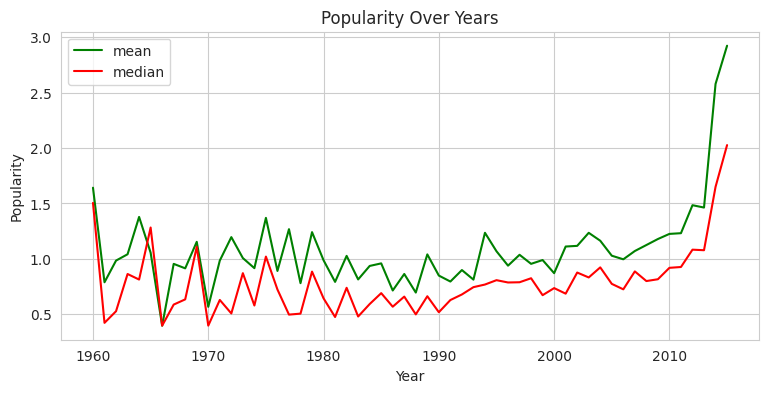

```python
#set style
sns.set_style('whitegrid')
#set x, y axis data
#x1, y1 for mean data; x2, y2 for median data
x1, y1 = index_mean, p_mean
x2, y2 = index_median, p_median
#set size
plt.figure(figsize=(9, 4))
#plot line chart for mean and median
plt.plot(x1, y1, color = 'g', label = 'mean')
plt.plot(x2, y2, color = 'r', label = 'median')
#set title and labels
plt.title('Popularity Over Years')
plt.xlabel('Year')
plt.ylabel('Popularity');
#set legend
plt.legend(loc='upper left')
```

# Question 2: How is popularity distributed across various revenue levels in the last five years?

The popularity of movies has seen an upward trend in recent years, prompting an exploration into whether popularity differs across various revenue levels. Is there a correlation between higher revenue and increased popularity? This research, however, does not delve into the trend of revenue, as it can be influenced by numerous factors, including inflation. Despite the availability of adjusted data in the database, the analysis aims for simplicity.

Furthermore, even if a growing trend in movie revenue is identified, it does not necessarily imply a direct link to popularity solely by examining the revenue trend line chart year by year.

```python
# quartile function
def cut_into_quantile(dfname ,column_name):
# find quartile, max and min values
    min_value = dfname[column_name].min()
    first_quantile = dfname[column_name].describe()[4]
    second_quantile = dfname[column_name].describe()[5]
    third_quantile = dfname[column_name].describe()[6]
    max_value = dfname[column_name].max()
# Bin edges that will be used to "cut" the data into groups
    bin_edges = [ min_value, first_quantile, second_quantile, third_quantile, max_value]
# Labels for the four budget level groups
    bin_names = [ 'Low', 'Medium', 'Moderately High', 'High']
# Creates budget_levels column
    name = '{}_levels'.format(column_name)
    dfname[name] = pd.cut(dfname[column_name], bin_edges, labels=bin_names, include_lowest = True)
    return dfname
```

```python
# Choose the recent five years
df_years = [2011, 2012, 2013, 2014, 2015]

# Create an empty dataframe, df_q2
df_q2 = pd.DataFrame()

# For each year, perform the following procedure
for year in df_years:
    dfn = df[df['release_year'] == year]  # First, filter the dataframe with the selected year
    dfn2 = cut_into_quantile(dfn, 'revenue')  # Apply cut_into_quantile with the selected frame, store it in dfn2
    df_q2 = df_q2.append(dfn2)  # Append dfn2 to df_q2

df_q2.info()
```

```
<class 'pandas.core.frame.DataFrame'>
Int64Index: 816 entries, 3372 to 583
Data columns (total 16 columns):
 #   Column                Non-Null Count  Dtype
---  ------                --------------  -----
 0   id                    816 non-null    int64
 1   popularity            816 non-null    float64
 2   budget                816 non-null    float64
 3   revenue               816 non-null    float64
 4   original_title        816 non-null    object
 5   cast                  816 non-null    object
 6   director              816 non-null    object
 7   keywords              816 non-null    object
 8   runtime               816 non-null    int64
 9   genres                816 non-null    object
 10  production_companies  816 non-null    object
 11  release_date          816 non-null    datetime64[ns]
 12  vote_count            816 non-null    int64
 13  vote_average          816 non-null    float64
 14  release_year          816 non-null    int64
 15  revenue_levels        816 non-null    category
dtypes: category(1), datetime64[ns](1), float64(4), int64(4), object(6)
memory usage: 103.0+ KB
```

[output not shown]

```python
# group the dataframe we created above with each revenue levels in each year, find the popularity meadian
dfq2_summary = df_q2.groupby(['release_year','revenue_levels']).median()
dfq2_summary.tail(8)
```

| release_year | revenue_levels | id | popularity | budget | revenue | runtime | vote_count | vote_average |
| --- | --- | --- | --- | --- | --- | --- | --- | --- |
| 2014 | Low | 241945.0 | 0.751624 | 6000000.0 | 2940432.0 | 100.0 | 193.0 | 6.1 |
|  | Medium | 227296.0 | 0.984911 | 15000000.0 | 35002066.5 | 106.5 | 385.0 | 6.2 |
|  | Moderately High | 209451.0 | 1.904422 | 40000000.0 | 108782847.0 | 108.0 | 837.0 | 6.2 |
|  | High | 142277.0 | 3.838407 | 122500000.0 | 365983918.0 | 113.0 | 2218.5 | 6.8 |
| 2015 | Low | 273899.0 | 0.699932 | 10000000.0 | 3324330.0 | 103.0 | 231.0 | 5.7 |
|  | Medium | 276907.0 | 1.742286 | 15000000.0 | 40423945.0 | 106.0 | 472.0 | 6.3 |
|  | Moderately High | 266470.5 | 2.152641 | 32500000.0 | 98010656.0 | 114.0 | 767.0 | 6.3 |
|  | High | 214756.0 | 5.462138 | 108000000.0 | 368871007.0 | 121.0 | 1899.0 | 6.7 |

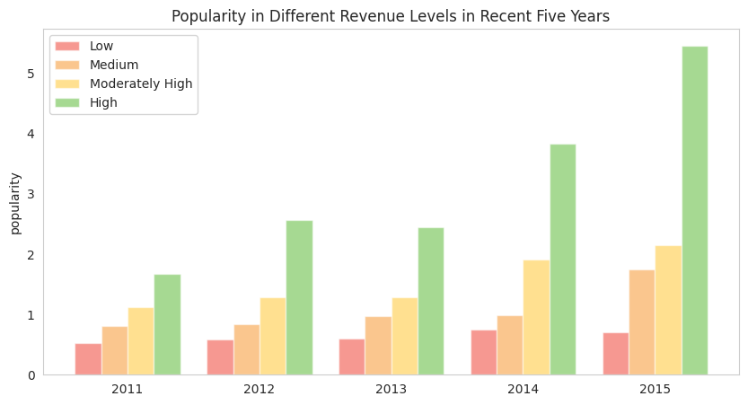

```python
# Setting the positions and width for the bars
pos = list(range(len(dfq2_summary.query('revenue_levels =="Low"'))))
width = 0.2

# Plotting the bars
fig, ax = plt.subplots(figsize=(10,5))

# Create a bar with Low data, in position pos,
plt.bar(pos,
        #using 'Low' data,
        dfq2_summary.query('revenue_levels =="Low"')['popularity'],
        # of width
        width,
        # with alpha 0.5
        alpha=0.5,
        # with color
        color='#EE3224',
        # with label Low
        label= 'Low')

# Create a bar with Medium data,
# in position pos + some width buffer,
plt.bar([p + width for p in pos],
        #using Medium data,
        dfq2_summary.query('revenue_levels =="Medium"')['popularity'],
        # of width
        width,
        # with alpha 0.5
        alpha=0.5,
        # with color
        color='#F78F1E',
        # with label Medium
        label='Medium')

# Create a bar with Moderately High data,
# in position pos + some width buffer,
plt.bar([p + width*2 for p in pos],
        #using Moderately High data,
        dfq2_summary.query('revenue_levels =="Moderately High"')['popularity'],
        # of width
        width,
        # with alpha 0.5
        alpha=0.5,
        # with color
        color='#FFC222',
        # with label Moderately High
        label='Moderately High')

# Create a bar with High data,
# in position pos + some width buffer,
plt.bar([p + width*3 for p in pos],
        #using High data,
        dfq2_summary.query('revenue_levels =="High"')['popularity'],
        # of width
        width,
        # with alpha 0.5
        alpha=0.5,
        # with color
        color='#4fb427',
        # with label High
        label='High')

# Set the y axis label
ax.set_ylabel('popularity')

# Set the chart's title
ax.set_title('Popularity in Different Revenue Levels in Recent Five Years')

# Set the position of the x ticks
ax.set_xticks([p + 1.5 * width for p in pos])

# Set the labels for the x ticks
ax.set_xticklabels([2011,2012,2013,2014,2015])

# Adding the legend and showing the plot
plt.legend( loc='upper left')
plt.grid()
plt.show()
```

It is evident that movies with higher revenue levels exhibit increased popularity over the recent five years.

The positive correlation between revenue level and popularity is reasonable, prompting consideration of how movie producers prioritize promotion to enhance revenue. Building upon the findings from the previous question, it can be inferred that movies with higher revenue levels consistently boast higher popularity compared to those with lower revenue levels. Thus, if we define a movie's success based on revenue, a noteworthy property is its elevated popularity.

However, we must now examine the distribution of score ratings among movies with different revenue levels. Does a high revenue level correspond to a higher score rating? This question will be explored in the following section.

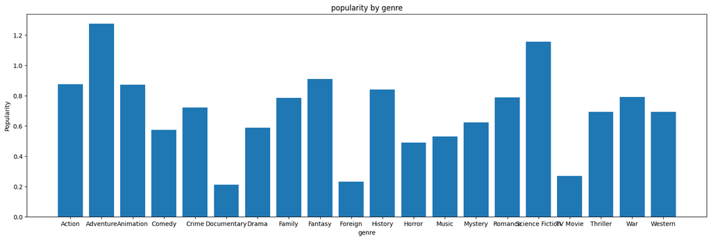

```python
plt.subplots(figsize=(20, 6))
plt.bar(genres_popularity.index, genres_popularity)
plt.title('popularity by genre')
plt.xlabel('genre')
plt.ylabel('Popularity');
```

So we can see that Adventure movies is the most popular genre.

What kinds of properties are associated with movies that have high revenues?

```python
# Continue to explore the data to address your additional research
#   questions. Add more headers as needed if you have more questions to
#   investigate.
sorted_revenue_biggest = df.sort_values(by=['revenue'], ascending = False).head(200)
sorted_revenue_biggest.head(1)
```

[output not shown]

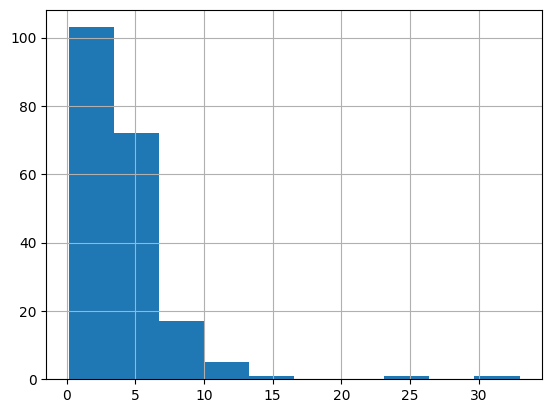

```python
sorted_revenue_biggest.popularity.hist()
```

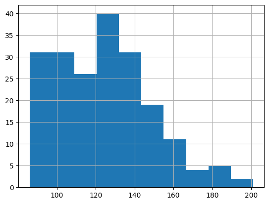

```python
sorted_revenue_biggest.runtime.hist()
```

```python
#Are short movies more popular?
shorter_movies = df.sort_values(by=['runtime'], ascending = False).head(200)
runtime = shorter_movies['runtime']
popularity = shorter_movies['popularity']
```

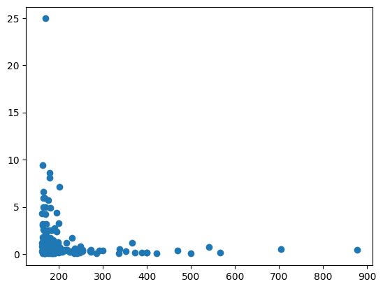

```python
plt.scatter(runtime, popularity)
plt.show()
```